#### Market for New Craft Brewery Market in the United States.

##### Prepared by Joe Scheder and Kyle Thomas for New Brewery Inc.

New Brewery Inc. would like to introduce a new IPA with a high alcohol content and bitterness. They would like to introduce this to a large market that currently favors having breweries producing beers with these characteristics.

The analysis is shown below.

```r
getwd()
```

```
## [1] "C:/Users/kthomas/Documents/SMU/DDS_CS1/rmarkdown"
```

```r
setwd ("C:\\Users\\kthomas\\Documents\\SMU\\DDS_CS1\\Data")
beers <- read.csv(file = "Beers.csv", sep=",", header=TRUE)
breweries <- read.csv(file = "Breweries.csv", sep=",", header=TRUE)

#Bring in additional population data. Via Us Cencus (https://www.census.gov/data/tables/2016/demo/popest/state-total.html)
uspop = read.csv("uspop.csv")
colnames(uspop) = c("State_Name", "State", "pop2016")

#head(beers)
kable(head(beers), "html", padding = 2, longtable = TRUE) %>%
kable_styling(bootstrap_options = "striped", full_width = F, position = "left")
```

[output not shown]

Beer_ID

ABV

IBU

Brewery_id

Style

Ounces

[output not shown]

1436

0.050

NA

409

American Pale Lager

12

[output not shown]

2265

0.066

NA

178

American Pale Ale (APA)

12

[output not shown]

2264

0.071

NA

178

American IPA

12

[output not shown]

2263

0.090

NA

178

American Double / Imperial IPA

12

[output not shown]

2262

0.075

NA

178

American IPA

12

[output not shown]

2261

0.077

NA

178

Oatmeal Stout

12

```r
#head(breweries)
kable(head(breweries), "html", padding = 2, longtable = TRUE) %>%
kable_styling(bootstrap_options = "striped", full_width = F, position = "left")
```

[output not shown]

Name

City

State

[output not shown]

NorthGate Brewing

Minneapolis

MN

[output not shown]

Against the Grain Brewery

Louisville

KY

[output not shown]

Jack’s Abby Craft Lagers

Framingham

MA

[output not shown]

Mike Hess Brewing Company

San Diego

CA

[output not shown]

Fort Point Beer Company

San Francisco

CA

[output not shown]

COAST Brewing Company

Charleston

SC

The number of breweries are present in each state

```r
library(plyr)
Statesum <- count(breweries, 'State')
Statesum <- Statesum[order(-Statesum$freq),]
colnames(Statesum) <- c("State", "Number of Breweries")
kable(Statesum, "html", padding = 2, longtable = TRUE) %>%
kable_styling(bootstrap_options = "striped", full_width = F, position = "left")
```

[output not shown]

State

Number of Breweries

[output not shown]

CO

47

[output not shown]

CA

39

[output not shown]

MI

32

[output not shown]

OR

29

[output not shown]

TX

28

[output not shown]

PA

25

[output not shown]

MA

23

[output not shown]

WA

23

[output not shown]

IN

22

[output not shown]

WI

20

[output not shown]

NC

19

[output not shown]

IL

18

[output not shown]

NY

16

[output not shown]

VA

16

[output not shown]

FL

15

[output not shown]

OH

15

[output not shown]

MN

12

[output not shown]

AZ

11

[output not shown]

VT

10

[output not shown]

ME

9

[output not shown]

MO

9

[output not shown]

MT

9

[output not shown]

CT

8

[output not shown]

AK

7

[output not shown]

GA

7

[output not shown]

MD

7

[output not shown]

OK

6

[output not shown]

IA

5

[output not shown]

ID

5

[output not shown]

LA

5

[output not shown]

NE

5

[output not shown]

RI

5

[output not shown]

HI

4

[output not shown]

KY

4

[output not shown]

NM

4

[output not shown]

SC

4

[output not shown]

UT

4

[output not shown]

WY

4

[output not shown]

AL

3

[output not shown]

KS

3

[output not shown]

NH

3

[output not shown]

NJ

3

[output not shown]

TN

3

[output not shown]

AR

2

[output not shown]

DE

2

[output not shown]

MS

2

[output not shown]

NV

2

[output not shown]

DC

1

[output not shown]

ND

1

[output not shown]

SD

1

[output not shown]

WV

1

Data integrity checks were done. See the first 6 observations and the last six observations of the data.

```r
colnames(breweries)[1] <- "Brewery_id"
beerandbrew <- merge(breweries, beers, by=c("Brewery_id"), all= FALSE)
colnames(beerandbrew)[2] <- "Brewery"
colnames(beerandbrew)[5] <- "Beer"

#head(beerandbrew)

kable(head(beerandbrew), "html", padding = 2, longtable = TRUE) %>%
kable_styling(bootstrap_options = "striped", full_width = F, position = "left")
```

[output not shown]

Brewery

City

State

Beer

Beer_ID

ABV

IBU

Style

Ounces

[output not shown]

NorthGate Brewing

Minneapolis

MN

Pumpion

2689

0.060

38

Pumpkin Ale

16

[output not shown]

NorthGate Brewing

Minneapolis

MN

Stronghold

2688

0.060

25

American Porter

16

[output not shown]

NorthGate Brewing

Minneapolis

MN

Parapet ESB

2687

0.056

47

Extra Special / Strong Bitter (ESB)

16

[output not shown]

NorthGate Brewing

Minneapolis

MN

Get Together

2692

0.045

50

American IPA

16

[output not shown]

NorthGate Brewing

Minneapolis

MN

Maggie’s Leap

2691

0.049

26

Milk / Sweet Stout

16

[output not shown]

NorthGate Brewing

Minneapolis

MN

Wall’s End

2690

0.048

19

English Brown Ale

16

```r
#tail(beerandbrew)
kable(tail(beerandbrew), "html", padding = 2, longtable = TRUE) %>%
kable_styling(bootstrap_options = "striped", full_width = F, position = "left")
```

[output not shown]

Brewery_id

Brewery

City

State

Beer

Beer_ID

ABV

IBU

Style

Ounces

[output not shown]

556

Ukiah Brewing Company

Ukiah

CA

Pilsner Ukiah

98

0.055

NA

German Pilsener

12

[output not shown]

557

Butternuts Beer and Ale

Garrattsville

NY

Porkslap Pale Ale

49

0.043

NA

American Pale Ale (APA)

12

[output not shown]

557

Butternuts Beer and Ale

Garrattsville

NY

Snapperhead IPA

51

0.068

NA

American IPA

12

[output not shown]

557

Butternuts Beer and Ale

Garrattsville

NY

Moo Thunder Stout

50

0.049

NA

Milk / Sweet Stout

12

[output not shown]

557

Butternuts Beer and Ale

Garrattsville

NY

Heinnieweisse Weissebier

52

0.049

NA

Hefeweizen

12

[output not shown]

558

Sleeping Lady Brewing Company

Anchorage

AK

Urban Wilderness Pale Ale

30

0.049

NA

English Pale Ale

12

Additonally check of data were complete to make sure that data was present for most of the data being analyzed. The number of blanks in each column is shown.

```r
#colSums(is.na(beerandbrew))
kable(colSums(is.na(beerandbrew)), "html", padding = 2, longtable = TRUE) %>%
kable_styling(bootstrap_options = "striped", full_width = F, position = "left")
```

[output not shown]

0

[output not shown]

0

[output not shown]

0

[output not shown]

0

[output not shown]

0

[output not shown]

0

[output not shown]

62

[output not shown]

1005

[output not shown]

0

[output not shown]

0

In order to find the right market for the new beer. The median alcohol content and international bitterness unit was computed for each state. Data is visualized in bar charts.

```r
library("reshape2")
abvandibu <- aggregate(beerandbrew[, 7:8], list(beerandbrew$State), median, na.rm=TRUE)
abvandibu$ABV = abvandibu$ABV*100

abvandibumelt <- melt(abvandibu, id=c("Group.1"))
abvandibumelt <-abvandibumelt[order(-abvandibumelt$variable),]
```

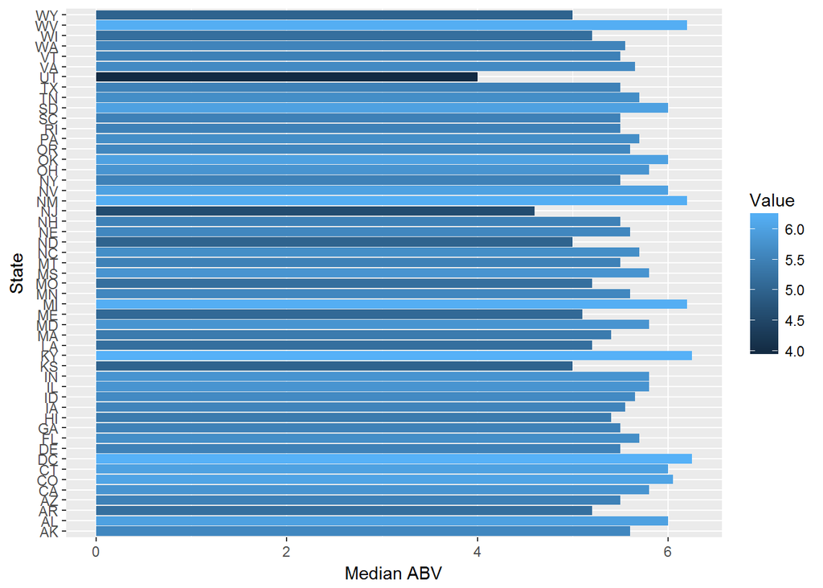

```r
colnames(abvandibumelt) <- c("State", "ABVIBU", "Value")

ABVMED <- abvandibumelt[abvandibumelt$ABVIBU == "ABV", ]
IBUMED <- abvandibumelt[abvandibumelt$ABVIBU == "IBU", ]

library("ggplot2")
qplot(x=State, data=ABVMED, geom ="bar", weight = Value, fill = Value, ylab = 'Median ABV') + coord_flip()
```

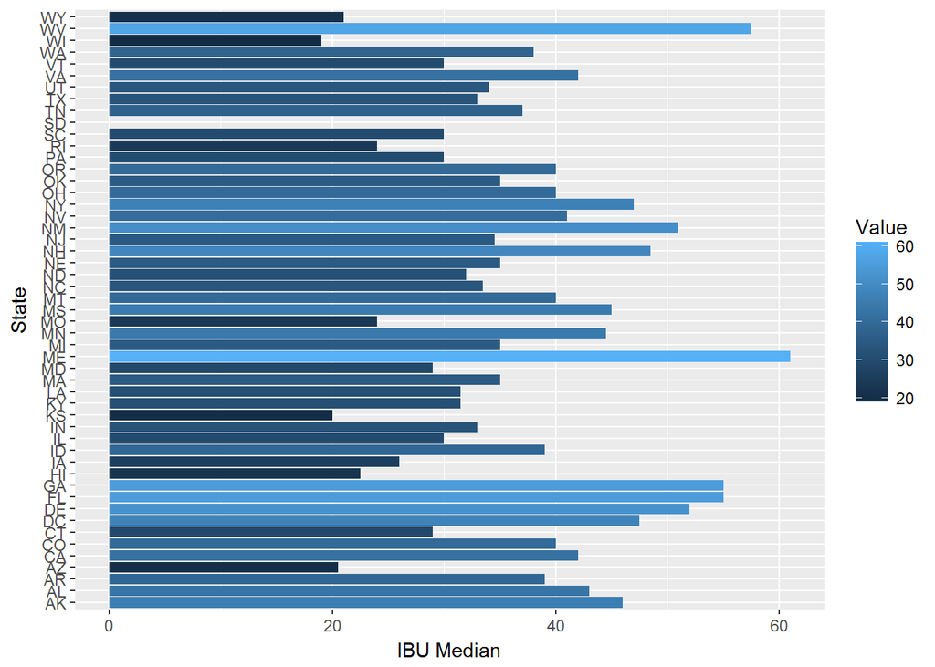

```r
qplot(x=State, data=IBUMED, geom ="bar", weight=Value, fill = Value, ylab = 'IBU Median') + coord_flip()
```

The state that has the maximum alcoholic (ABV) beer:

```r
maxabv <- beerandbrew[which.max(beerandbrew$ABV),]
#maxabv$State
kable(maxabv$State, "html", padding = 2, longtable = TRUE) %>%
kable_styling(bootstrap_options = "striped", full_width = F, position = "left")
```

[output not shown]

The state that has the most bitter (IBU) beer:

```r
 maxibu <- beerandbrew[which.max(beerandbrew$IBU),]
#maxibu$State
kable(maxibu$State, "html", padding = 2, longtable = TRUE) %>%
kable_styling(bootstrap_options = "striped", full_width = F, position = "left")
```

[output not shown]

Finally a summary statistics table for the ABV variable.

```r
sumtable <- summary(beerandbrew$ABV)
Statistics <- c("Min.", "1st Qu.",  "Median", "Mean", "3rd Qu.", "Max.", "NA's" )
Values <- c(sumtable[1], sumtable[2],  sumtable[3], sumtable[4], sumtable[5], sumtable[6], sumtable[7] )
sumdf <- data.frame(Statistics, Values)
kable(sumdf[2], "html", padding = 2, longtable = TRUE) %>%
kable_styling(bootstrap_options = "striped", full_width = F, position = "left")
```

[output not shown]

Values

[output not shown]

0.00100

[output not shown]

0.05000

[output not shown]

0.05600

[output not shown]

0.05977

[output not shown]

0.06700

[output not shown]

0.12800

[output not shown]

62.00000

Shown now is the apparent relationship between the bitterness of the beer and its alcoholic content.

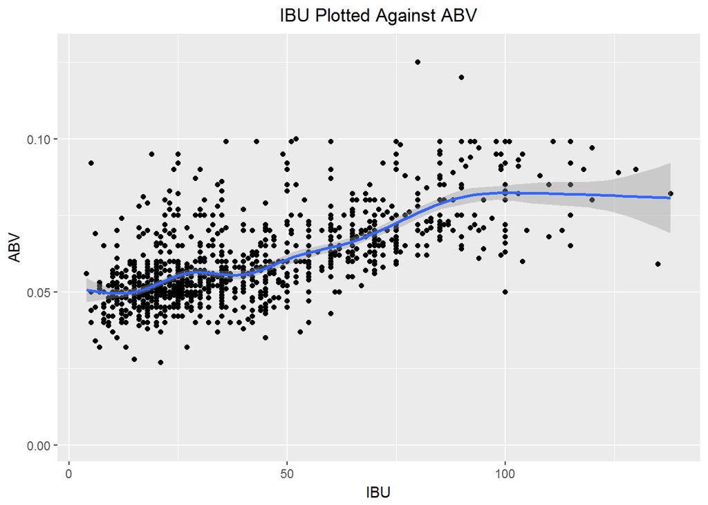

```r
#Changed old scatter plot to ggplot
# scatter.smooth(beerandbrew$ABV, beerandbrew$IBU, ylab = "IBU",
#                xlab = "ABV", col= 4, main = "ABV vs IBU")


ggScatter = ( ggplot(beerandbrew, aes(x=IBU, y=ABV)) + geom_point() +
                labs(title="IBU Plotted Against ABV") + theme(plot.title = element_text(hjust = 0.5)) +
                geom_smooth())

ggScatter
```

Based on the analysis of the data for breweries by state, there is reason to believe that states that there are certain states that have both high median alcohol content and bitter beers.

A basic market analysis was conducted to determine which states could use a high ABV and high IBU beer. This was done by first creating a combined metric for IBU and ABV. The new metric was simply multiplying ABV with IBU. Next, the 3 states with the lowest median IBU and ABV beers were identified (the combined metric). The three states with the lowest combined ABV and IBU values are Wisconsin, Kansas, and Wyoming. Interestingly, these states are within a reasonable trucking distance, so this new brewery could be located in a low cost area and the beer could be shipped to these identified states.

```r
#Merge us population with main dataframe

beerandbrew = merge(beerandbrew, uspop, by = "State")

#We need a way to compare IBU and ABV at the same time. This can be done by simply multiplying together
#IBU and ABV to make a combined measure.

colnames(abvandibu) = c("State", "ABV", "IBU")

needBeer = merge(abvandibu, uspop, by="State")
needBeer["combined"]= needBeer$IBU*needBeer$ABV

#Based only on a ABV and IBU
mostneeded = head(needBeer[order(needBeer$combined),],10)
mostneeded
```

```
##    State  ABV  IBU    State_Name   pop2016 combined
## 49    WI 5.20 19.0    .Wisconsin 5,778,708    98.80
## 17    KS 5.00 20.0       .Kansas 2,907,289   100.00
## 51    WY 5.00 21.0      .Wyoming   585,501   105.00
## 4     AZ 5.50 20.5      .Arizona 6,931,071   112.75
## 12    HI 5.40 22.5       .Hawaii 1,428,557   121.50
## 25    MO 5.20 24.0     .Missouri 6,093,000   124.80
## 40    RI 5.50 24.0 .Rhode Island 1,056,426   132.00
## 45    UT 4.00 34.0         .Utah 3,051,217   136.00
## 13    IA 5.55 26.0         .Iowa 3,134,693   144.30
## 32    NJ 4.60 34.5   .New Jersey 8,944,469   158.70
```

```r
#highest Populations - this part of the analysis was scrapped
# needAndPop = tail(mostneeded[order(mostneeded$pop2016),],3)
#
# needAndPop
```

Below is a map of the United States that shows the combined ABV and IBU metric as a heat map. States that have higher median ABV and IBU beers are warmer in color. States that have lower median ABV and IBU beers are cooler in color. This graphic is particularly helpful for visualizing regional preferences and determining where a new brewery should be located.

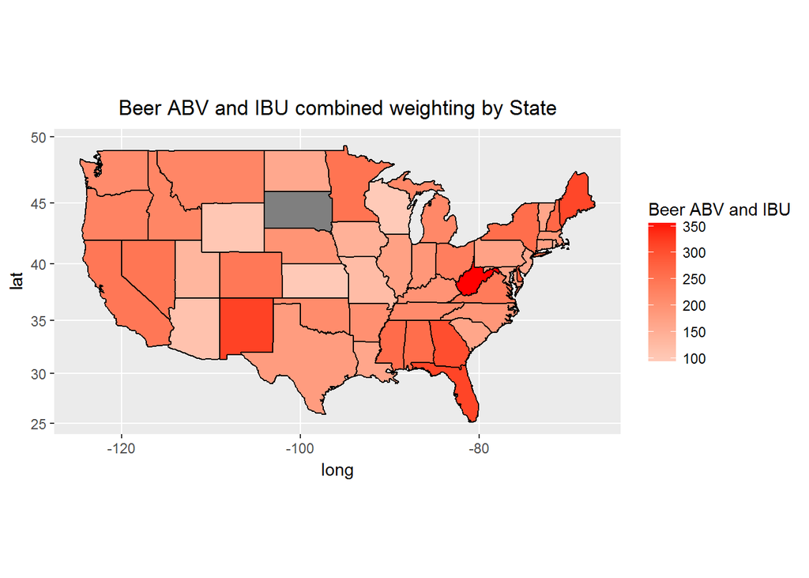

```r
#I ended up redoing this section for only median data. I kept the code in the script for histroical reasons
# beerandbrew$State_Name = tolower(beerandbrew$State_Name)
# beerandbrew$State_Name = sub(".","", beerandbrew$State_Name)
# colnames(beerandbrew)[11] = "region"
#
# stateMap = map_data("state")
# mapdf = merge(stateMap, beerandbrew, by="region")
# mapdf["combined"] = mapdf$ABV*mapdf$IBU
# mapdf = mapdf[order(mapdf$order),]
#
# #Right now this is IBU, I will change it to what ever metrix we want to evaluate target states.
# #Thanks stackoverflow
# ggplot(mapdf, aes(x=long,y=lat,group=group))+
#   geom_polygon(aes(fill=IBU))+
#   geom_path()+
#   #scale_fill_gradientn(colours=rev(heat.colors(10)),na.value="grey50")+
#   scale_fill_gradient2(low="blue", mid="white", high="red", na.value="grey50", space="Lab", guide="colourbar")+
#   coord_map()

####MEDIAN ONLY DATA#####
needBeer$State_Name = tolower(needBeer$State_Name)
needBeer$State_Name = sub(".", "", needBeer$State_Name)
colnames(needBeer)[4] = "region"
stateMap2 = map_data("state")
mapdf2 = data.frame(merge(stateMap2, needBeer, by="region"), stringsAsFactors = FALSE)

#This was an attempt to only show the three selected states.... more trouble than it was worth
# for (x in 1:nrow(mapdf2)) {
#
# if(! mapdf2[7,x]  %in% c(" NJ", " MO", " AZ"))  {
#   mapdf2[11,x] = ""}
#
#   #else {mapdf2[11,x] = mapdf2[11,x]}
#
# }



ggplot(mapdf2, aes(x=long,y=lat,group=group))+
  geom_polygon(aes(fill=combined))+
  geom_path()+
  #scale_fill_gradientn(colours=rev(heat.colors(10)),na.value="grey50")+
  scale_fill_gradient2(low="blue", mid="white", high="red", na.value="grey50", space="Lab", guide="colourbar")+
  labs(fill="Beer ABV and IBU", title="Beer ABV and IBU combined weighting by State", xlab="", ylab="")+
  theme(plot.title = element_text(hjust = 0.5))+
  coord_map()
```